# Airport Market Leakage Code Library and Analysis

Eugene Chong

May 9, 2019

# 1 – Summary and Motivation

This document summarizes the code used to clean and analyze the data used for Professor Megan S. Ryerson and Professor Amy M. Kim’s mega-region airport market leakage study.

The code:

- Reads in and cleans:
  - Data from the Origin and Destination Survey (DB1B), a 10% random sample of airline tickets published by the Bureau of Transportation Statistics.
  - Data from the Air Carrier Statistics database (T-100), a dataset of domestic non-stop segments reported by US air carriers and published by the Bureau of Transportation Statistics.
  - Shapefiles and network distance data calculated in and exported from ArcMap.
- Calculates each airport’s market share for every census tract in a study region using the higher of the airport’s:
  - Direct flight utility and
  - Connecting flight utility

This code base was adapted from the code that Professors Ryerson and Kim wrote for their paper “A drive for better air service: How air service imbalances across neighboring regions integrate air and highway demands” (2018). It was updated to:

- Adopt Tidyverse conventions, which improve readability and performance.
- Combine the direct and connecting flight utilities, which had previously been considered separately, into a single calculation.
- Allow users to tweak the coefficients used for the utility calculations by a number of standard errors in any direction.
- Automate the utility and market share calculations; users can repeat the analysis shown here in other locations by specifying a study region and destination airport, assuming the necessary ArcMap analyses were completed.
- Automatically generate maps and figures displaying the distribution of airport market shares in a study region.

Future iterations of the code base will:

- Calculate the network distance between census tract and/or zipcode centroids and study region airports by calling the Google Maps API, removing ArcMap from the workflow.
- Incorporate functionality to read and analyze DB1B data from different years simultaneously, allowing us examine airport market leakage in a study region longitudinally.
- Incorporate analysis of ARC ticket purchase data, allowing us to estimate the environmental impact of airport market leakage.

In this vignette, we examine how market shares differ among airports in the Texas-Louisiana-Oklahoma mega-region for flights to Seattle SEA and Atlanta ATL.

## 1.1 Data Directory

The data currently live in the Box directory for the Airport Market Leakage study. Users can sync the directory to their desktop and access it with the following call, updating it to the directory on their device as necessary.

```r
setwd("C:/Users/eugen/Box Sync/Airport Leakage")
```

# 2 – Setup

## 2.1 Load Packages

We call the following packages:

- **tidyverse:** Contains the data cleaning (*dplyr*), functional programming (*purrr*), and plotting (*ggplot2*) tools that we use throughout the code.
- **sf:** Provides tools to manipulate and plot simple feature objects (i.e., geometries like census tracts).
- **tmap:** Includes functionality to create interactive maps. Currently unused.
- **ggrepel:** Extends the labeling functionality in ggplot2.
- **gridExtra:** Adds functionality to display multiple ggplots side-by-side.

```r
library(tidyverse)
library(sf)
library(tmap)
library(ggrepel)
library(gridExtra)
```

## 2.2 Create a Map Theme

We create a theme to give our maps a consistent appearance.

```r
mapTheme <- function(base_size = 12) {
  theme(
    text = element_text( color = "black"),
    plot.title = element_text(size = 14,colour = "black"),
    plot.subtitle = element_text(face = "italic"),
    plot.caption = element_text(hjust = 0),
    axis.ticks = element_blank(),
    panel.background = element_blank(), axis.title = element_blank(),
    axis.text = element_blank(),
    axis.title.x = element_blank(),
    axis.title.y = element_blank(),
    panel.grid.minor = element_blank(),
    panel.border = element_rect(colour = "black", fill = NA, size = 2)
  )
}
```

# 3 – Read Data

## 3.1 – Shapefiles

First, we read in the geometries necessary for our analysis: the census tracts and airports for each of our study regions. Currently, we include the Southeast and Texas mega-regions, though for purposes of this vignette we will examine only the Texas region.

The census tracts come in shapefile format already and simply need to be read in. The airports for each region come as coordinates in csv files. We project the coordinates and transform the airports into shapefiles.

```r
# Census tracts for each region
Southeast <- st_read("03.26 Ophelia_GIS + update data/02 piedmont atlantic/GIS/mergedregion/studyarea.shp") %>%
  rownames_to_column(var = "ID")

Texas <- st_read("03.26 Ophelia_GIS + update data/03 Texas/shapefiles/merged.shp") %>%
  rownames_to_column(var = "ID")

# Airports for each region
Southeast_airports_shp <- read_csv("Code/Utility and Market Share/Coding Dummy Data/Region 2/Airport Points/airport.csv") %>%
  st_as_sf(coords = c("longitude", "latitude"), crs = 4269, remove = FALSE)

Texas_airports_shp <- read_csv("Code/Utility and Market Share/Coding Dummy Data/Region 1/Airport Points/airport.csv") %>%
  st_as_sf(coords = c("longitude", "latitude"), crs = 4269, remove = FALSE)
```

## 3.2 – DB1B

Next, we read in the DB1B data. In this vignette, we look at the data for the second quarter of 2015.

```r
datTix2015_2 <- read_csv("Data/DB1BTix/Origin_and_Destination_Survey_DB1BTicket_2015_2.csv", col_names = TRUE)
datCoup2015_2 <- read_csv("Data/DB1Bcoup/Origin_and_Destination_Survey_DB1BCoupon_2015_2.csv", col_names = TRUE)
datSegment2015 <- read_csv("Data/T_100Seg/Seg_2015.csv", col_names = TRUE)
```

# 4 – Clean Data

Next, we clean the DB1B data to prepare it for the analysis. We:

- Narrow the datasets to our variables of interest.
- Find the total number of flights flown between each Origin and Destination pair.
- Join the tables together by Itinerary ID and O-D pairing.
- Remove unnecessary dataframes to reduce processing load.

```r
datCoup2015_2.clean <- datCoup2015_2 %>%
  select(ItinID, Coupons, Origin, RPCarrier, Passengers, Dest)
rm(datCoup2015_2)

datTix2015_2.clean <- datTix2015_2 %>%
  select(ItinID, Coupons, Origin, RoundTrip, FarePerMile, RPCarrier, Passengers, ItinFare, MilesFlown)
rm(datTix2015_2)

datSegment2015.clean <- datSegment2015 %>%
  select(DEPARTURES_SCHEDULED, DEPARTURES_PERFORMED, SEATS, CARRIER, ORIGIN, DEST, AIR_TIME, RAMP_TO_RAMP) %>%
  mutate(OrgDest = paste(ORIGIN, DEST, sep = "")) %>%
  group_by(OrgDest) %>%
  summarise(Total_DepScheduled = sum(DEPARTURES_SCHEDULED))
rm(datSegment2015)

# join Tix, Coup, and Segment
db1b_2015.joined <- datTix2015_2.clean %>%
  left_join(datCoup2015_2.clean, by = "ItinID") %>%
  rename(Origin = Origin.y) %>%
  select(-contains(".y"), -Origin.x) %>%
  rename_at(.vars = vars(ends_with(".x")),
            .funs = funs(sub("[.]x$", "", .))) %>%
  mutate(OrgDest = paste(Origin, Dest, sep = "")) %>%
  left_join(datSegment2015.clean, by = "OrgDest") %>%
  mutate(RoundTrip1 = case_when(RoundTrip == 0 ~ 1,
                                RoundTrip == 1 ~ 2)) %>%
  select(-RoundTrip) %>%
  rename(RoundTrip = RoundTrip1) %>%
  mutate(Connection = ifelse(Coupons / RoundTrip > 1.4, 2, (Coupons / RoundTrip)),
         DestCnx = paste(Dest, Connection, sep = ""))

# remove unnecessary data
rm(datCoup2015_2.clean, datTix2015_2.clean, datSegment2015.clean)
```

# 5 – Analysis

## 5.1 – Define Regions’ Airports

We create a vector defining each airport in the study regions. Each of these airports must have a corresponding “NEAR” csv generated by the ArcMap Network Analyst tool.

```r
TX_airports <- sort(c("DFW", "OKC", "SHV", "AUS", "HOU", "IAH", "DAL", "SAT"))

SE_airports <- sort(c("ATL", "BHM", "CHA", "HSV", "SAV", "TYS"))
```

## 5.2 – Set Variables of Interest

- **study_area:** Texas. This points to the Texas region census tracts shapefile we imported earlier.
- **dest:** “SEA”. This is the three-letter code for the destination airport.
- **travel_speed:** This is the flight speed we use for calculating the “travel time” in the connecting flight utility function.
- **dwell_time:** This is the dwell time we use in the connecting flight utility function. It is also part of the “travel” time calculation.
- **file_path:** This is the file path where the “NEAR” csvs generated by the ArcMap Network Analyst tool are located.
- **Coefficients:** Here, we specify for each coefficient whether we want to use the base value, the lower bound, or the base value plus/minus any number of standard deviations.
  - **Lower Bound:** To use the coefficient lower bound, specify “1” for the corresponding `*_lower_bound_on` object.
  - *x* Standard Deviations from Base Value: For example, to use a coefficient value that is 2 standard deviations away from the base value, specify “0” for the `*_lower_bound_on` object and “2” for the `*_error_multiplier` object.
  - **Base value:** To use the base value, specify “0” for both the `*_lower_bound_on` and `*_error_multiplier` objects.

```r
study_area <- Texas
airport_reg <- TX_airports
dest <- "SEA"

travel_speed <- 550
dwell_time <- 1.5

file_path <- "C:/Users/eugen/Box Sync/Airport Leakage/Code/Utility and Market Share/Coding Dummy Data/Region 1"

## direct
# airfare
dir_airfare_lower_bound_on <- 0 # do you want to use the lower bound or not?  1 or 0
dir_airfare_error_multiplier <- 0 # user input - how many standard errors away from base coefficient?  Only applies if "lower_bound_on" is 0.

# frequency
dir_freq_lower_bound_on <- 0
dir_freq_error_multiplier <- 0

# ground access distance
dir_groundDist_lower_bound_on <- 0
dir_groundDist_error_multiplier <- 0

## connecting
# airfare
cxn_airfare_lower_bound_on <- 0
cxn_airfare_error_multiplier <- 0

# travel time
cxn_travelTime_lower_bound_on <- 0
cxn_travelTime_error_multiplier <- 0

# ground access time
cxn_groundTime_lower_bound_on <- 0
cxn_groundTime_error_multiplier <- 0
```

Per Ryerson and Kim’s paper, we use the following values for the coefficient bases, standard errors, and lower bounds:

### Direct (substitute) v Direct (local)

| —– | Airfare | Frequency | Ground Access Distance |
| --- | --- | --- | --- |
| Units | Euros | No. of Daily Flights | Kilometers |
| Base | -0.18 | 0.36 | -0.85 |
| Std. Error | -0.08 | 0.13 | -0.25 |
| Lower Bound | -0.02 | 0.09 | -1.35 |

### Direct (substitute) v Connecting (local)

| —– | Airfare | Travel Time | Ground Access Time |
| --- | --- | --- | --- |
| Units | Euros | Hours | Minutes |
| Base | -1.1 | -0.047 | -1.57 |
| Std. Error | 13 | 2.8 | 8.4 |
| Lower Bound | -0.93 | -0.01 | -1.94 |

This is where we hardcode the values for coefficients, standard errors, and lower bounds that we use in the utility calculations.

```r
## direct
# airfare
dir_airfare_base <- -0.18 # base coefficient
dir_airfare_error <- -0.08 # standard error
dir_airfare_lower_bound <- -0.02
dir_airfare_coefficient <- ifelse(dir_airfare_lower_bound_on == 1,
                                  dir_airfare_lower_bound,
                                  dir_airfare_base + dir_airfare_error * dir_airfare_error_multiplier)

# frequency
dir_freq_base <- 0.36
dir_freq_error <- 0.13
dir_freq_lower_bound <- 0.09
dir_freq_coefficient <- ifelse(dir_freq_lower_bound_on == 1,
                               dir_freq_lower_bound,
                               dir_freq_base + dir_freq_error * dir_freq_error_multiplier)

# ground access distance
dir_groundDist_base <- -0.85
dir_groundDist_error <- -0.25
dir_groundDist_lower_bound <- -1.35
dir_groundDist_coefficient <- ifelse(dir_groundDist_lower_bound_on == 1,
                                     dir_groundDist_lower_bound,
                                     dir_groundDist_base + dir_groundDist_error * dir_groundDist_error_multiplier)

## connecting
# airfare
cxn_airfare_base <- -1.1
cxn_airfare_error <- 13
cxn_airfare_lower_bound <- -0.93
cxn_airfare_coefficient <- ifelse(cxn_airfare_lower_bound_on == 1,
                                  cxn_airfare_lower_bound,
                                  cxn_airfare_base + cxn_airfare_error * cxn_airfare_error_multiplier)

# travel time
cxn_travelTime_base <- -0.047
cxn_travelTime_error <- 2.8
cxn_travelTime_lower_bound <- -0.01
cxn_travelTime_coefficient <- ifelse(cxn_travelTime_lower_bound_on == 1,
                                     cxn_travelTime_lower_bound,
                                     cxn_travelTime_base + cxn_travelTime_error * cxn_travelTime_error_multiplier)

# ground access time
cxn_groundTime_base <- -1.57
cxn_groundTime_error <- 8.4
cxn_groundTime_lower_bound <- -1.94
cxn_groundTime_coefficient <- ifelse(cxn_groundTime_lower_bound_on == 1,
                                     cxn_groundTime_lower_bound,
                                     cxn_groundTime_base + cxn_groundTime_error * cxn_groundTime_error_multiplier)
```

## 5.3 – Clean Study Area Shapefile

We give the study area shapefile an ID that will match the IDs used in the “NEAR” csvs.

```r
study_area$ID <- as.numeric(study_area$ID)
study_area <- study_area %>%
  mutate(ID = ID -1) %>%
  dplyr::select(ID, GEOID, geometry)
```

## 5.4 – Find Average Fares, Frequencies, and Distances

Next we find the average fares, frequencies, and flight distances for each airport in the study region to the destination airport. For round trip itineraries, we cut the fare and distance in half, assuming that a one-way itinerary would be exactly half the distance and cost.

```r
OriginDest_Fare_Freq <- db1b_2015.joined %>%
  filter(Origin %in% airport_reg, # flights beginning in our study region
         Dest == dest) %>% # and ending at our destination
  group_by(Origin, RoundTrip, Connection) %>%
  summarize(Avg_Fare = mean(ItinFare),
            Avg_Miles = mean(MilesFlown),
            Freq = mean(Total_DepScheduled)) %>%
  mutate(Avg_Fare = Avg_Fare / RoundTrip, # if round trip, only take half the fare
         Avg_Miles = Avg_Miles / RoundTrip) %>%
  ungroup() %>%
  group_by(Origin, Connection) %>%
  summarize(Avg_Fare = mean(Avg_Fare), # now that we have gotten fare and miles per segment, average out the roundtrip column.
            Avg_Miles = mean(Avg_Miles),
            Freq = mean(Freq))
```

## 5.5 – Prepare “NEAR” CSVs

We read in the “NEAR” csvs that were exported from the ArcMap Network Analyst tool. A member of the team previously updated those csvs to include distance in kilometers as well as the calculation for direct flight utility for each airport. We remove those here so that the `distance_imports2` object matches the original output from ArcMap.

```r
setwd(file_path)

file_list <- list.files(pattern = "*.csv")

distance_imports <- lapply(file_list, function(x){
  read_csv(x) %>% filter(!is.na(ObjectID))})

# Change the names of the lists to be the name of the corresponding airport in the study region
names(distance_imports) <- str_extract(list.files(file_path, pattern = "*.csv", full.names = FALSE), airport_reg)

# Remove the km conversion and utility function columns.  This is now the export of the Route function, i.e., the output from ArcMap.
distance_imports2 <- lapply(distance_imports, function(x){
  x %>% select(-c(starts_with("KM"), ID, starts_with("UT")))})
```

## 5.5 – Create New Columns with Distance in KM, Average Fare, Frequency, and Direct and Connecting Utilities

We find the following variables:

- Average fare of a direct flight to the destination
- Frequency of direct flights to the destination
- Ground access distance in kilometers from each census tract to each airport
- Average fare of a connecting flight to the destination
- Average total travel time for a connecting flight to the destination
- Ground access time from each census tract to each airport
- Utility of taking a direct flight from the airport to the destination
- Utility of taking a connecting flight from the airport to the destination

We find those variables for each airport (new columns) with respect to each census tract (the rows). We do so using the function `map2()` from the Tidyverse package `purrr`. This allows us to run a custom function iteratively over two lists: the `distance_imports2` object from the previous step as well as the names of the elements of that object (i.e., the names of the airports in the study region). Using a looping function like `map2()` allows us to quickly repeat this analysis in study regions that may have different numbers of census tracts or airports. `map2()` also has the advantage of being significantly faster than using custom for loops. Lastly, we use `map2()` because it can accept two input lists, as opposed to `lapply()` (used in the previous code segment), which can only accept one.

```r
distance_imports3 <- map2(distance_imports2, names(distance_imports2), function(y, z) {

  # direct variables and utility column names
  Direct_Avg_Fare_name <- rlang::sym(paste("Direct_Avg_Fare_", z, sep = ""))
  Freq_name <- rlang::sym(paste("Freq_", z, sep = ""))
  Ground_access_dist_name <- rlang::sym(paste("Ground_access_dist_KM_", z, sep = ""))
  Direct_UT_name <- rlang::sym(paste("Direct_UT_", z, sep = ""))

  # connecting variables and utility column names
  Connecting_Avg_Fare_name <- rlang::sym(paste("Connecting_Avg_Fare_", z, sep = ""))
  Travel_time_name <- rlang::sym(paste("Travel_time_", z, sep = ""))
  Ground_access_time_name <- rlang::sym(paste("Ground_access_time_", z, sep = ""))
  Connecting_UT_name <- rlang::sym(paste("Connecting_UT_", z, sep = ""))

  y %>% mutate(ID = IncidentID - 1,
               # Direct variables and Utility
               !!Direct_Avg_Fare_name := ifelse(
                 # ifelse statements: if there is no direct/connecting flight from this origin to the destination, it returns NA.
                 sum(!is.na(OriginDest_Fare_Freq$Avg_Fare[which(OriginDest_Fare_Freq$Origin == z &
                                                                  OriginDest_Fare_Freq$Connection == 1)]) != 0),
                 OriginDest_Fare_Freq$Avg_Fare[which(OriginDest_Fare_Freq$Origin == z &
                                                       OriginDest_Fare_Freq$Connection == 1)], # select for "no connections"
                 NA),
               !!Freq_name := ifelse(
                 sum(!is.na(OriginDest_Fare_Freq$Freq[which(OriginDest_Fare_Freq$Origin == z &
                                                              OriginDest_Fare_Freq$Connection == 1)]) != 0),
                 OriginDest_Fare_Freq$Freq[which(OriginDest_Fare_Freq$Origin == z &
                                                   OriginDest_Fare_Freq$Connection == 1)],
                 NA),
               !!Ground_access_dist_name := Total_Length * 1.609344, # convert to KM
               !!Direct_UT_name := dir_airfare_coefficient * (!!Direct_Avg_Fare_name)/100 +
                 dir_freq_coefficient * log((!!Freq_name)/365) +
                 dir_groundDist_coefficient * log((!!Ground_access_dist_name)),
               # Connecting variables and Utility
               !!Connecting_Avg_Fare_name := ifelse(
                 sum(!is.na(OriginDest_Fare_Freq$Avg_Fare[which(OriginDest_Fare_Freq$Origin == z &
                                                                  OriginDest_Fare_Freq$Connection == 2)]) != 0), # select for "yes connections"
                 OriginDest_Fare_Freq$Avg_Fare[which(OriginDest_Fare_Freq$Origin == z &
                                                       OriginDest_Fare_Freq$Connection == 2)],
                 NA),
               !!Travel_time_name := ifelse(
                 sum(!is.na(OriginDest_Fare_Freq$Avg_Miles[which(OriginDest_Fare_Freq$Origin == z &
                                                                   OriginDest_Fare_Freq$Connection == 2)]) != 0),
                 OriginDest_Fare_Freq$Avg_Miles[which(OriginDest_Fare_Freq$Origin == z &
                                                        OriginDest_Fare_Freq$Connection == 2)] / # take average mileage for flights with cxns
                   travel_speed + # divide that by travel speed
                   dwell_time, # lastly, add dwell time
                 NA),
               !!Ground_access_time_name := Total_Time,
               !!Connecting_UT_name := cxn_airfare_coefficient * (!!Connecting_Avg_Fare_name)/100 +
                 cxn_travelTime_coefficient * (log(!!Travel_time_name)) +
                 cxn_groundTime_coefficient * (log(!!Ground_access_time_name))) %>%
    dplyr::select(ID, everything(), -c(ObjectID:IncidentID, Total_Length))
})
```

The output is a list object `distance_imports3` that, like the input `distance_imports2`, contains a certain number of elements, each with the name of an airport in the study region. Those elements are dataframes with the same number of rows each as there are census tracts in the study region. They also contain new columns for each variable we’ve specified above, but the columns have different names in each list element; they include a suffix that matches the three-letter code for the relevant airport. The structure of `distance_imports3` is shown below.

```r
str(distance_imports3)
```

```
## List of 8
##  $ AUS:Classes 'tbl_df', 'tbl' and 'data.frame': 7430 obs. of  10 variables:
##   ..$ ID                       : num [1:7430] 0 1 2 3 4 5 6 7 8 9 ...
##   ..$ Total_Time               : num [1:7430] 191 189 200 200 181 ...
##   ..$ Direct_Avg_Fare_AUS      : num [1:7430] 306 306 306 306 306 ...
##   ..$ Freq_AUS                 : num [1:7430] 385 385 385 385 385 385 385 385 385 385 ...
##   ..$ Ground_access_dist_KM_AUS: num [1:7430] 340 308 328 330 325 ...
##   ..$ Direct_UT_AUS            : num [1:7430] -5.49 -5.4 -5.46 -5.46 -5.45 ...
##   ..$ Connecting_Avg_Fare_AUS  : num [1:7430] 298 298 298 298 298 ...
##   ..$ Travel_time_AUS          : num [1:7430] 5.93 5.93 5.93 5.93 5.93 ...
##   ..$ Ground_access_time_AUS   : num [1:7430] 191 189 200 200 181 ...
##   ..$ Connecting_UT_AUS        : num [1:7430] -11.6 -11.6 -11.7 -11.7 -11.5 ...
##  $ DAL:Classes 'tbl_df', 'tbl' and 'data.frame': 7430 obs. of  10 variables:
##   ..$ ID                       : num [1:7430] 0 1 2 3 4 5 6 7 8 9 ...
##   ..$ Total_Time               : num [1:7430] 37.9 255.7 266.6 267 44.9 ...
##   ..$ Direct_Avg_Fare_DAL      : num [1:7430] 224 224 224 224 224 ...
##   ..$ Freq_DAL                 : num [1:7430] 407 407 407 407 407 407 407 407 407 407 ...
##   ..$ Ground_access_dist_KM_DAL: num [1:7430] 46.7 441.2 460.5 463.2 59 ...
##   ..$ Direct_UT_DAL            : num [1:7430] -3.63 -5.54 -5.58 -5.58 -3.83 ...
##   ..$ Connecting_Avg_Fare_DAL  : num [1:7430] 235 235 235 235 235 ...
##   ..$ Travel_time_DAL          : num [1:7430] 5.42 5.42 5.42 5.42 5.42 ...
##   ..$ Ground_access_time_DAL   : num [1:7430] 37.9 255.7 266.6 267 44.9 ...
##   ..$ Connecting_UT_DAL        : num [1:7430] -8.38 -11.37 -11.44 -11.44 -8.64 ...
##  $ DFW:Classes 'tbl_df', 'tbl' and 'data.frame': 7430 obs. of  10 variables:
##   ..$ ID                       : num [1:7430] 0 1 2 3 4 5 6 7 8 9 ...
##   ..$ Total_Time               : num [1:7430] 23.1 265.8 276.7 277.1 30.1 ...
##   ..$ Direct_Avg_Fare_DFW      : num [1:7430] 341 341 341 341 341 ...
##   ..$ Freq_DFW                 : num [1:7430] 3571 3571 3571 3571 3571 ...
##   ..$ Ground_access_dist_KM_DFW: num [1:7430] 31.7 465.1 484.4 487.1 44 ...
##   ..$ Direct_UT_DFW            : num [1:7430] -2.73 -5.01 -5.05 -5.05 -3.01 ...
##   ..$ Connecting_Avg_Fare_DFW  : num [1:7430] 363 363 363 363 363 ...
##   ..$ Travel_time_DFW          : num [1:7430] 6.19 6.19 6.19 6.19 6.19 ...
##   ..$ Ground_access_time_DFW   : num [1:7430] 23.1 265.8 276.7 277.1 30.1 ...
##   ..$ Connecting_UT_DFW        : num [1:7430] -9 -12.84 -12.9 -12.91 -9.42 ...
##  $ HOU:Classes 'tbl_df', 'tbl' and 'data.frame': 7430 obs. of  10 variables:
##   ..$ ID                       : num [1:7430] 0 1 2 3 4 5 6 7 8 9 ...
##   ..$ Total_Time               : num [1:7430] 260.9 23.6 34.5 34.9 247.3 ...
##   ..$ Direct_Avg_Fare_HOU      : num [1:7430] 252 252 252 252 252 ...
##   ..$ Freq_HOU                 : num [1:7430] 147 147 147 147 147 147 147 147 147 147 ...
##   ..$ Ground_access_dist_KM_HOU: num [1:7430] 452.7 32.5 51.8 54.4 428.6 ...
```

[output cut: 34 more lines]

```
##   ..$ Connecting_Avg_Fare_SAT  : num [1:7430] 293 293 293 293 293 ...
##   ..$ Travel_time_SAT          : num [1:7430] 6.13 6.13 6.13 6.13 6.13 ...
##   ..$ Ground_access_time_SAT   : num [1:7430] 242 209 220 220 231 ...
##   ..$ Connecting_UT_SAT        : num [1:7430] -11.9 -11.7 -11.8 -11.8 -11.9 ...
##  $ SHV:Classes 'tbl_df', 'tbl' and 'data.frame': 7430 obs. of  10 variables:
##   ..$ ID                       : num [1:7430] 0 1 2 3 4 5 6 7 8 9 ...
##   ..$ Total_Time               : num [1:7430] 196 302 313 313 185 ...
##   ..$ Direct_Avg_Fare_SHV      : logi [1:7430] NA NA NA NA NA NA ...
##   ..$ Freq_SHV                 : logi [1:7430] NA NA NA NA NA NA ...
##   ..$ Ground_access_dist_KM_SHV: num [1:7430] 342 456 475 478 337 ...
##   ..$ Direct_UT_SHV            : num [1:7430] NA NA NA NA NA NA NA NA NA NA ...
##   ..$ Connecting_Avg_Fare_SHV  : num [1:7430] 525 525 525 525 525 525 525 525 525 525 ...
##   ..$ Travel_time_SHV          : num [1:7430] 4.2 4.2 4.2 4.2 4.2 ...
##   ..$ Ground_access_time_SHV   : num [1:7430] 196 302 313 313 185 ...
##   ..$ Connecting_UT_SHV        : num [1:7430] -14.1 -14.8 -14.9 -14.9 -14 ...
```

## 5.6 – Choose Higher Utility

We gave the columns different names in order to facilitate flattening the list below. We use the `reduce()` function to join the list elements using a series of `left_joins()`, giving us a single very wide dataframe with one row per census tract and a set of variable columns for each airport.

```r
distance_imports4 <- distance_imports3 %>% purrr::reduce(left_join, by = "ID") %>% # join list dataframes together into one dataframe
  left_join(study_area, by = "ID") # join with shapefile

str(distance_imports4)
```

```
## Classes 'tbl_df', 'tbl' and 'data.frame':    7430 obs. of  75 variables:
##  $ ID                       : num  0 1 2 3 4 5 6 7 8 9 ...
##  $ Total_Time.x             : num  191 189 200 200 181 ...
##  $ Direct_Avg_Fare_AUS      : num  306 306 306 306 306 ...
##  $ Freq_AUS                 : num  385 385 385 385 385 385 385 385 385 385 ...
##  $ Ground_access_dist_KM_AUS: num  340 308 328 330 325 ...
##  $ Direct_UT_AUS            : num  -5.49 -5.4 -5.46 -5.46 -5.45 ...
##  $ Connecting_Avg_Fare_AUS  : num  298 298 298 298 298 ...
##  $ Travel_time_AUS          : num  5.93 5.93 5.93 5.93 5.93 ...
##  $ Ground_access_time_AUS   : num  191 189 200 200 181 ...
##  $ Connecting_UT_AUS        : num  -11.6 -11.6 -11.7 -11.7 -11.5 ...
##  $ Total_Time.y             : num  37.9 255.7 266.6 267 44.9 ...
##  $ Direct_Avg_Fare_DAL      : num  224 224 224 224 224 ...
##  $ Freq_DAL                 : num  407 407 407 407 407 407 407 407 407 407 ...
##  $ Ground_access_dist_KM_DAL: num  46.7 441.2 460.5 463.2 59 ...
```

[output cut: 64 more lines]

Then, we keep only the direct and connecting utility columns for each airport and throw out the rest for readability.

```r
distance_imports5 <- distance_imports4 %>%
  select(ID, GEOID, grep("UT", colnames(distance_imports4), value = TRUE)) # every column is the utility of flying connecting or direct from an airport
```

We use another looping function to choose, for each airport, the higher value between the direct and connecting flight utilities.

```r
distance_imports6 <- map(airport_reg, function(z) {

  # Column names.  These columns will be "choose the higher of the connecting or direct utilities".
  Higher_UT_name <- rlang::sym(paste("Higher_UT_", z, sep = ""))

  distance_imports5 %>% mutate(
    !!Higher_UT_name := do.call(pmax, # for each pair of Utility columns containing each respective airport name, choose the higher value
                                c(distance_imports5 %>% select(contains(paste(z))),
                                  na.rm = TRUE))) %>% # remove NAs.  If an airport does not have a direct flight to a dest, it would have NAs
    select(ID, GEOID, contains("Higher_UT_")) # give us only ID, GEOID, and the new "Higher Utility" column
  }) %>%
  purrr::reduce(left_join, by = c("ID", "GEOID")) # unlist and combine into one dataframe

distance_imports7 <- distance_imports6 %>%
  gather(Airport, Utility, grep("UT", colnames(distance_imports6), value = TRUE)) %>%
  arrange(ID, GEOID)
```

## 5.7 – Calculate Market Share

Using the utilities chosen in the previous step, we calculate each airport’s market share in each census tract for flights to the chosen destination. We then join it back to the `study_area` object, which contains the spatial information we need to map these market shares.

```r
distance_imports8 <- distance_imports7 %>%
  group_by(ID, GEOID) %>%
  mutate(Airport = gsub("Higher_UT_", "", Airport), # remove "Higher_UT_" from Airport column
         Total_Mkt = sum(exp(Utility)), # Sum of exponentiated utilities for every airport from each census tract (i.e., the denominator)
         Mkt_Share = exp(Utility) / Total_Mkt) %>% ungroup() # Market share for each airport from each census tract

distance_imports9 <- distance_imports8 %>%
  left_join(study_area, by = c("ID", "GEOID")) %>%
  dplyr::select(ID, GEOID, Airport, Mkt_Share, geometry)
```

## 5.8 – Final Data Outputs

We produce two outputs for our two flavors of map.

- **All Market Shares:** Contains a column for each airport’s market share.
- **Highest Market Share:** Includes a column for only the airport with the highest market share.

```r
# every airport has its market share as a separate column
all_Mkt_Shares <- distance_imports9 %>%
  spread(Airport, Mkt_Share) %>%
  st_as_sf()

# only the airport with the highest market share is included.
highest_Mkt_Share <- distance_imports9 %>%
  group_by(ID, GEOID) %>%
  filter(Mkt_Share == max(Mkt_Share, na.rm = TRUE)) %>%
  arrange(ID, GEOID) %>%
  st_as_sf()
```

# 6 – Plots

## 6.1 – Discretize

We create a function for rounding each airport’s market share to the highest tenth.

```r
discretize <- function(x, Airport) {
  x %>% mutate(fill_breaks = case_when(Airport < 0.1 ~ 0.1,
                                       Airport < 0.2 ~ 0.2,
                                       Airport < 0.3 ~ 0.3,
                                       Airport < 0.4 ~ 0.4,
                                       Airport < 0.5 ~ 0.5,
                                       Airport < 0.6 ~ 0.6,
                                       Airport < 0.7 ~ 0.7,
                                       Airport < 0.8 ~ 0.8,
                                       Airport < 0.9 ~ 0.9,
                                       Airport < 1.0 ~ 1.0))
}
```

## 6.2 – Texas to Seattle: Airport with the Highest Market Share for Each Tract

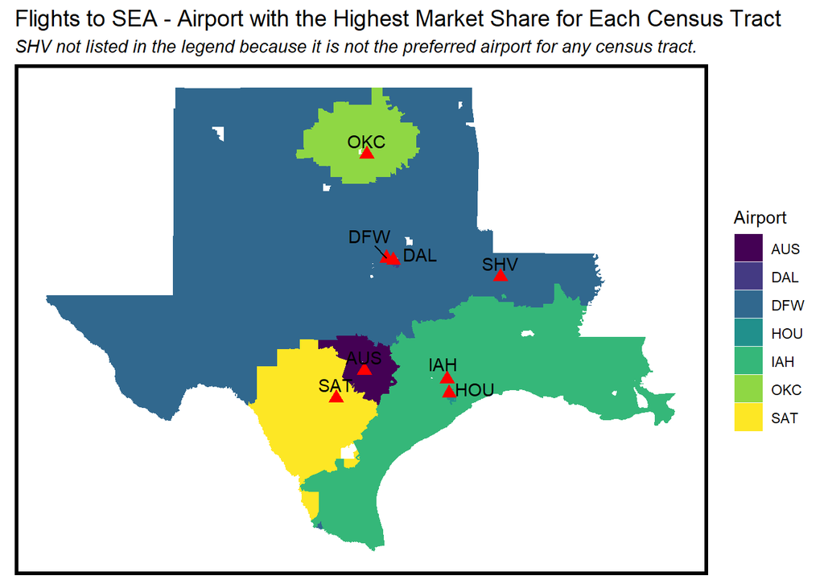

## 6.3 – AUS to SEA Market Shares

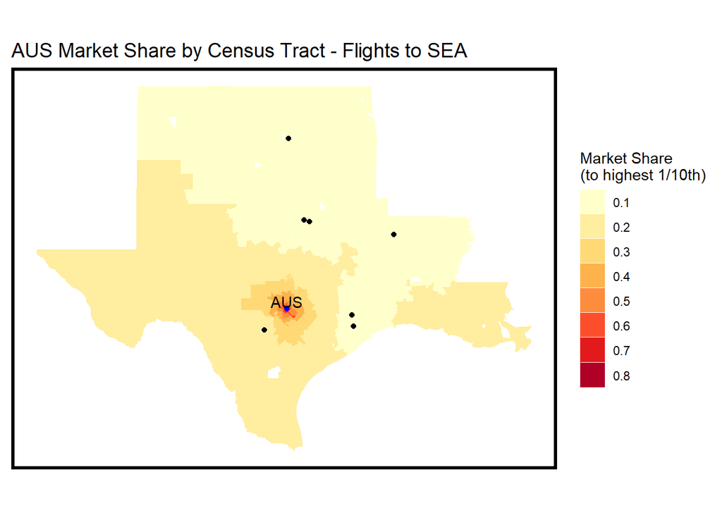

## 6.4 – DFW to SEA Market Shares

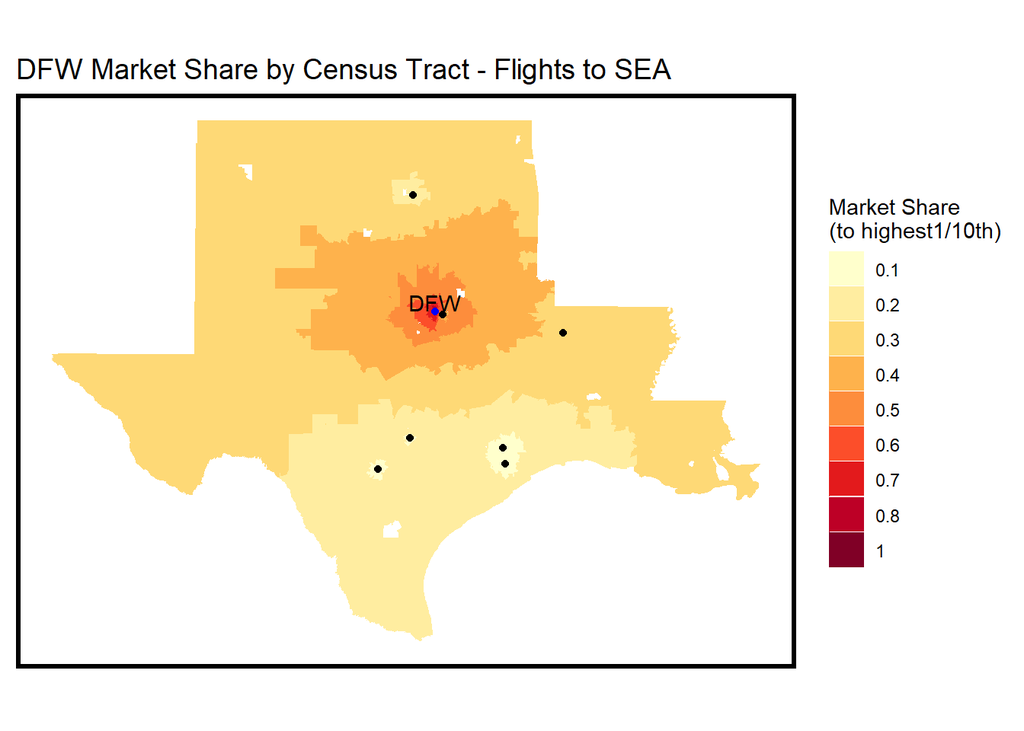

## 6.5 – Descriptive Plots

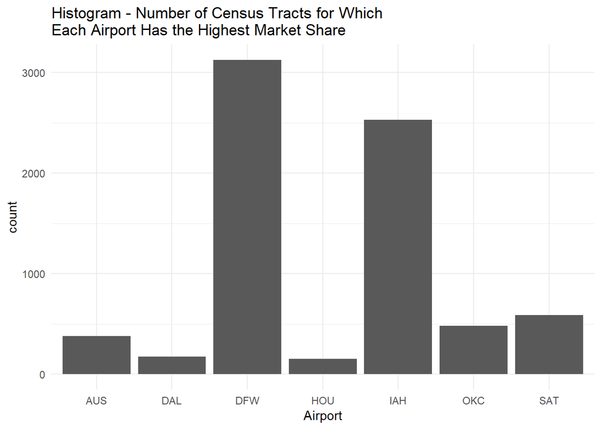

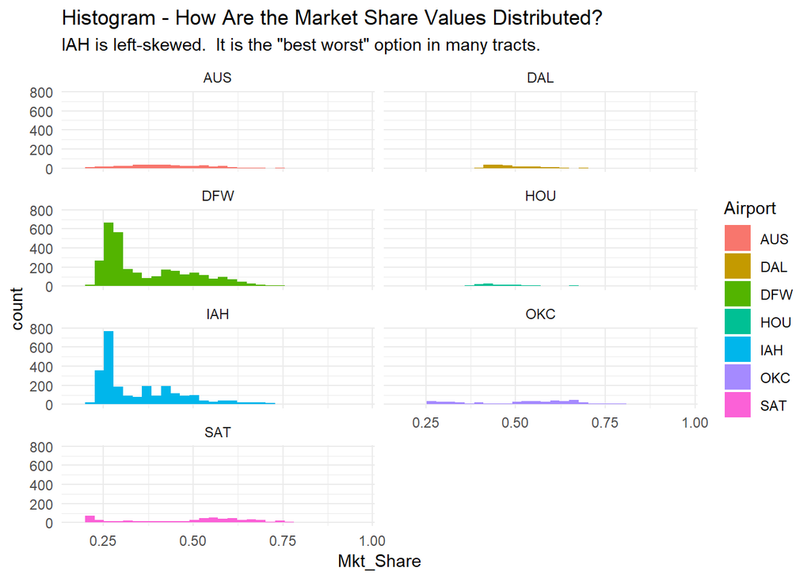

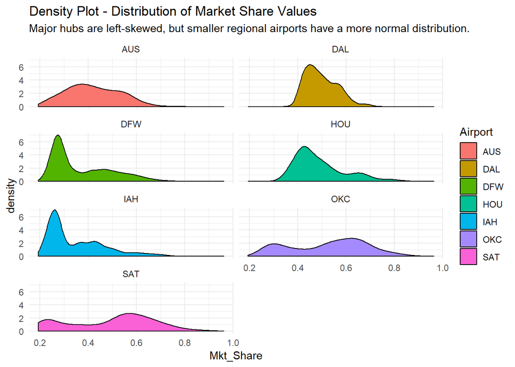

# 7 – Repeat for ATL

We repeat the entire analysis that preceded, but using ATL as the destination.

## 7.1 – ATL and SEA Plots Together

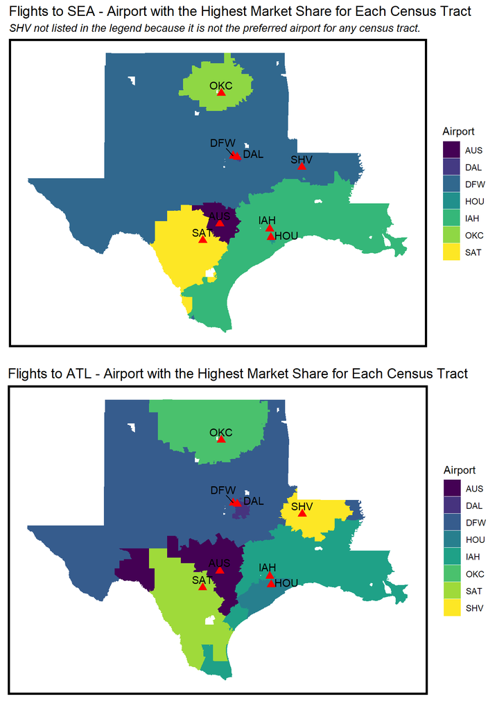

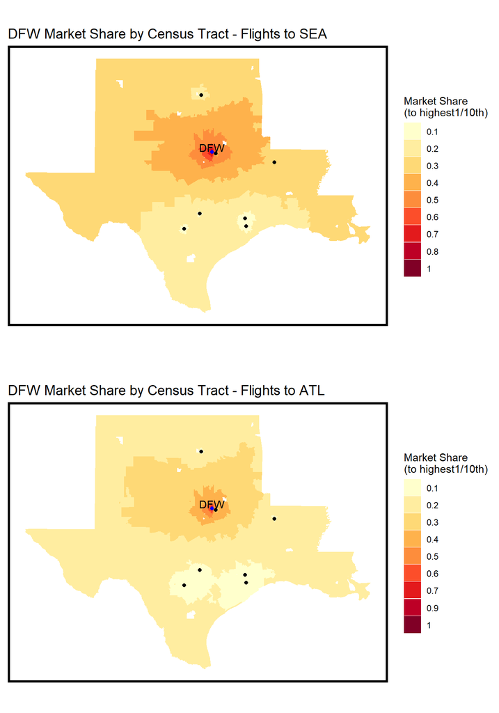

# 8 – Repeat with New Coefficients

Lastly, we repeat the analysis for both destinations (SEA and ATL), but this time we use the lower bounds for `Ground access distance`, `Travel time`, and `Ground access time`.

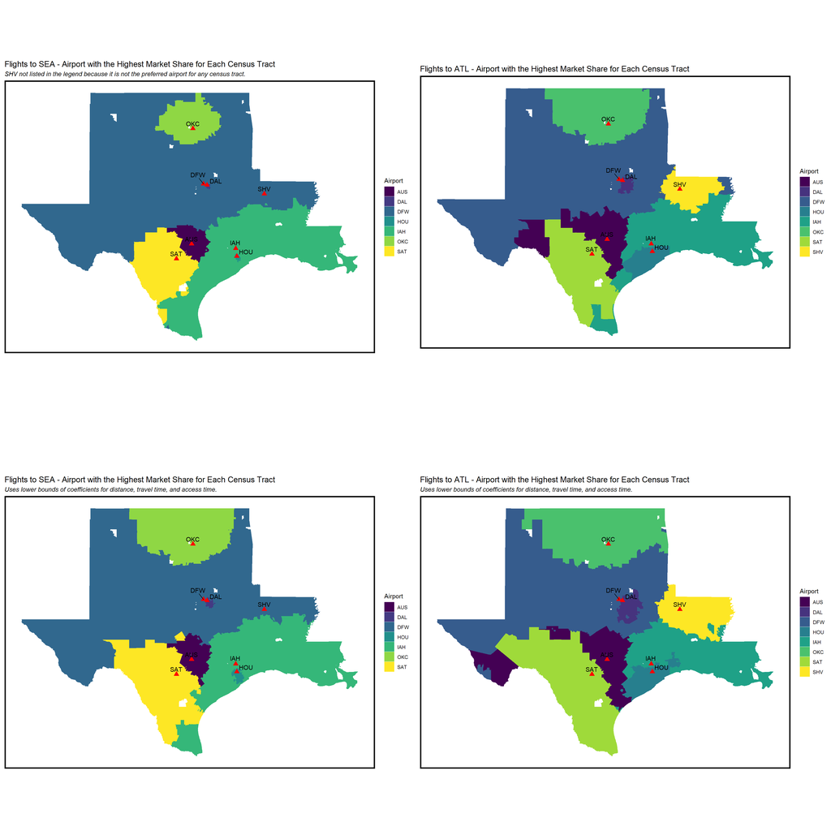

```r
grid.arrange(SEA_mkt_share, ATL_mkt_share, SEA_mkt_share_lower_bounds, ATL_mkt_share_lower_bounds, nrow=2, ncol=2)
```

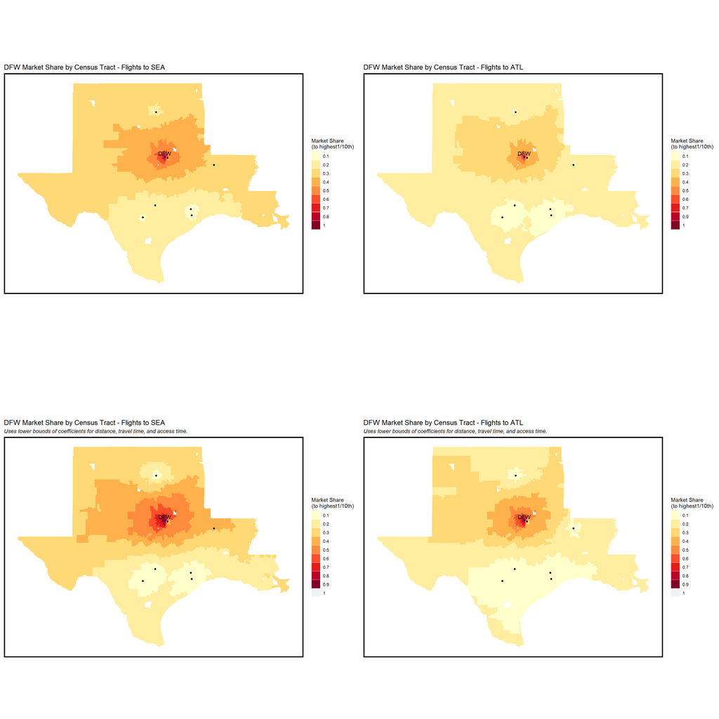

```r
grid.arrange(DFW_plot, DFW_plot_ATL, DFW_plot_SEA_lower_bounds, DFW_plot_ATL_lower_bounds, nrow=2, ncol=2)
```